# optimal_permute_marginal

Author

Affiliation

[Professor Simon Jackman](https://simonjackman.netlify.app)

University of Sydney

# 1 Definitions

## 1.1 Tables

A table $\mathcal{T}$ of $n$ observations (rows) spanning $m$ variables (columns) is a sample from the *joint* distribution of those $m$ variables, possibly iid.

## 1.2 Permutations

Let $i \in 1, \ldots, n$ index the rows of $\mathcal{T}$. Denote row $i$ as $\mathcal{T}_i$.

Let $\sigma: \{ 1, \ldots, n \} \mapsto \{ 1, \ldots, n \}$ be a permutation of the row indices, inducing a re-ordering of the rows of $\mathcal{T}$ with the resulting table denoted $\mathcal{T}^\sigma$. Let $\mathcal{P}$ be the set of all $n!$ permutations.

## 1.3 Independence: invariance to permutations

Let $p$ be a probability density function. If the rows of $\mathcal{T}$ are *independent* then $p(\mathcal{T}) = \prod_{i=1}^n \mathcal{T}_i$. By the commutativity of multiplication, independence of the rows of $\mathcal{T}$ implies $p(\mathcal{T}) = p(\mathcal{T}^\sigma)$ for all permutations $\sigma \in \mathcal{P}$.

## 1.4 Covariate classes

- Let the set $\mathcal{C} = C_1 \times C_2 ... C_m = \prod_{j=1}^m C_j$ be the Cartesian product of the sets of unique values of each of the $m$ columns of $\mathcal{T}$.
- Each element of $\mathcal{C}$ is a *covariate class*, a possible configuration of values of the columns of $\mathcal{T}$.
- $|\mathcal{C}| = v = \prod_{j=1}^m v_j$ is the number of covariate classes.
- Let $n_c$ be the number of rows in $\mathcal{T}$ with values on $X_1, \ldots, X_m$ corresponding to covariate class $\mathcal{C}_c \in \mathcal{C}$.
- Not every covariate class need be observed in $\mathcal{T}$; $n_c = 0$ in these cases.
- Dependencies across the columns of $\mathcal{T}$ manifest as unevenness in the distribution of data across covariate classes $n_c$.

# 2 Example

We have a selection of variables from an Australian Census micro-data files (the Confidential Unit Record File from the 2021 Census), spanning 148,888 records and 8 variables.

Each variable spans the number of discrete values show in the following table:

| variable | v<sub>j</sub> |
| --- | --- |
| SEXP | 2 |
| INGP_binary | 2 |
| RELP_collapsed | 10 |
| ANCP_collapse | 8 |
| MSTP | 4 |
| AGE_continuous | 20 |
| UNI | 2 |
| INCP_continous | 9 |

There are accordingly 460,800 possible covariate classes, of which 35,765 are observed in the data.

The histogram of case counts in each of the covariate classes is shown in the following figure.

```
Storing counts in `nn`, as `n` already present in input
ℹ Use `name = "new_name"` to pick a new name.
```

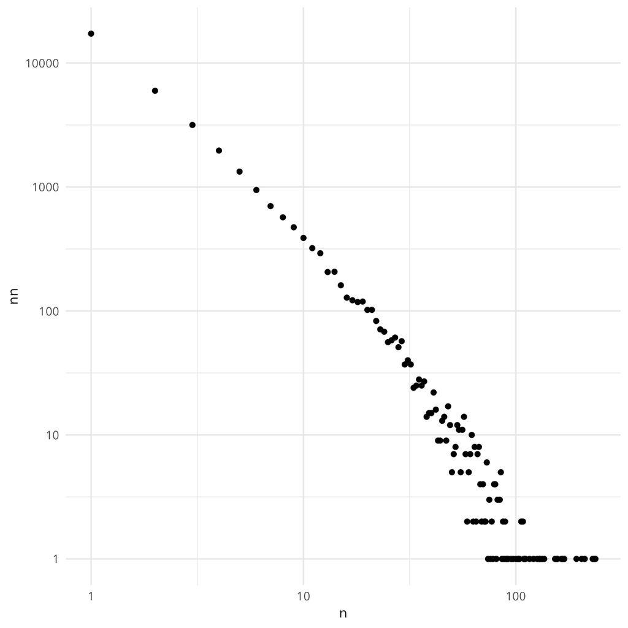

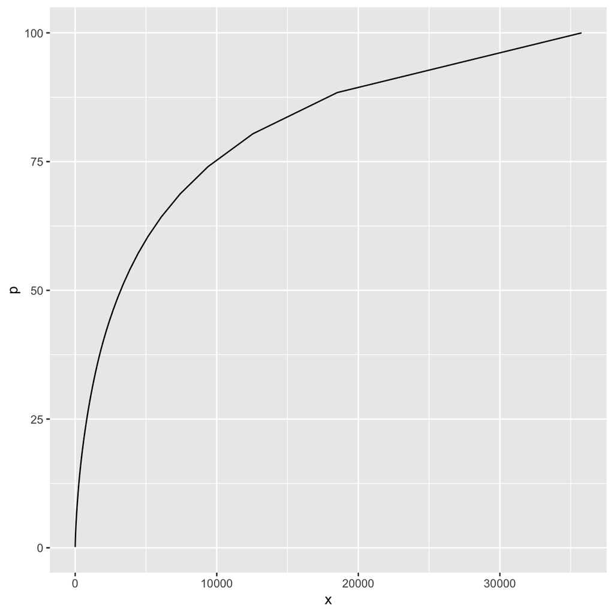

# 3 Task

Given

- knowledge of the desired marginal distributions of each column variable
- a “guide” master table that supplies some (?) information about the dependencies across the $p$ variables

can we recover a sample synthetic table that preserves the marginal distributions, but is otherwise “close” to the master table?

# 4 Sample application

The ABS provides a 1% sample of micro data from the Census, the “guide” master table in this example.  
Separately, the Census provides the marginal distributions of many variables for small areas (SA1, SA2, CED, POA, etc). We seek synthetic tables of micro data for these small areas.

# 5 An idea

Each column $j$ of $\mathcal{T}$, $X_j$, has a *frequency distribution*, a table with entries $n_{jk}$, counts of how often we observe $X_{ij} = k$, where $k \in 1, \ldots, m_j$ indexes the unique values of $X_j$. This frequency distribution induces partitions of $X_j$ into $m_j$ subsets $X_{jk} = \{i : X_{ij} = k \}$. A permutation of those partitions, $\sigma_j = \{ \sigma_j(X_{j1}), \ldots, \sigma_j(X_{j\,m_j}) \}$, induces a reordering of the rows of column $X_j$, but that keeps intact each subset $X_{jk}$.

Combinatoric across columns